# **CA1** Alireza Karimi

# **Part1:** Relationship between Binomial and Bernoulli Distributions

## **1_1:**

In the first question, we need to implement a function similar to numpy.random.binomial() as demonstrated in the code snippet below.

```python
import numpy as np

bin_trails = np.random.binomial(size=5000, n=500, p= 0.5)
display(bin_trails)
```

```
array([256, 247, 255, ..., 252, 226, 269])
```

Since we need to perform this action for all various percentages, we can utilize the following approach

```python
import numpy as np

def binomial(size, n, p):
    choices = np.random.choice([0, 1], size=size * n, replace=True, p=[1-p, p])
    bin_array = np.array(choices).reshape(size, n)
    row_sums = np.sum(bin_array, axis=1)
    return row_sums

display(binomial(size = 5000, n = 500 , p = 0.5))
```

```
array([241, 264, 257, ..., 262, 258, 245])
```

## **1_2:**

In this question, we'll be utilizing the binomial function to calculate probabilities for different percentage scenarios. We can approach it in the following way:

```python
size = 5000
n = 500
prob = np.arange(0, 1.01, 0.01)
all_bin_trials = np.array([binomial(size, n, p) for p in prob])
display(all_bin_trials)
```

```
array([[  0,   0,   0, ...,   0,   0,   0],
       [  4,   8,   3, ...,   2,   9,   6],
       [ 13,  15,  11, ...,  12,  20,  10],
       ...,
       [490, 492, 498, ..., 487, 492, 493],
       [497, 494, 497, ..., 496, 493, 492],
       [500, 500, 500, ..., 500, 500, 500]])
```

```python
practical_avg = np.array([np.average(k) for k in all_bin_trials])
theoretical_avg = np.array([n * p for p in prob])
practical_var = np.array([np.var(k) for k in all_bin_trials])
theoretical_var = np.array([n * p * (1-p) for p in prob])
print(f"The practical average values are: \n{practical_avg}\n")
print(f"The theoretical average values are: \n{theoretical_avg}\n")
print(f"The practical variance values are: \n{practical_var}\n")
print(f"The theoretical variance values are: \n{theoretical_var}\n")
```

```
The practical average values are:
[  0.       5.019   10.016   15.0792  20.0234  24.933   29.9994  35.0598
  39.904   45.0564  50.081   55.0034  60.0276  64.9082  69.8948  75.061
  80.3074  84.9012  89.9128  94.9026 100.0266 105.3338 109.9084 115.0608
 120.2738 125.0658 130.0202 134.9664 140.0402 145.1296 149.8832 155.0644
 159.965  164.9    170.1608 174.9858 180.2662 185.2096 189.941  194.7564
 200.1488 204.9216 210.169  214.9524 220.3522 225.0428 230.0588 235.351
 239.9848 245.2474 249.7436 255.0038 259.8744 264.9774 269.994  274.8374
 279.8604 285.0586 289.735  295.0844 299.8936 305.2044 310.009  315.2346
 320.217  324.953  329.7936 335.2622 340.25   344.6444 349.8052 355.0372
 360.1134 365.0686 369.8354 375.2016 379.9668 385.0704 390.0068 395.1162
 399.9782 405.041  409.8848 415.0274 420.1284 425.1152 429.9522 435.077
 440.0498 444.9084 449.9306 455.0284 460.0294 465.0892 469.9652 475.0198
 479.9446 485.046  489.9492 495.0216 500.    ]

The theoretical average values are:
[  0.   5.  10.  15.  20.  25.  30.  35.  40.  45.  50.  55.  60.  65.
  70.  75.  80.  85.  90.  95. 100. 105. 110. 115. 120. 125. 130. 135.
 140. 145. 150. 155. 160. 165. 170. 175. 180. 185. 190. 195. 200. 205.
 210. 215. 220. 225. 230. 235. 240. 245. 250. 255. 260. 265. 270. 275.
 280. 285. 290. 295. 300. 305. 310. 315. 320. 325. 330. 335. 340. 345.
 350. 355. 360. 365. 370. 375. 380. 385. 390. 395. 400. 405. 410. 415.
 420. 425. 430. 435. 440. 445. 450. 455. 460. 465. 470. 475. 480. 485.
 490. 495. 500.]

The practical variance values are:
[  0.           5.035439    10.160944    14.54212736  19.39045244
  22.854111    28.25499964  31.51342396  36.549184    40.13201904
  45.598039    48.57338844  51.86643824  56.74217276  59.32853296
  65.268079    66.01610524  71.67663856  74.61319616  76.52111324
  78.69229244  85.30677756  85.41360944  86.98950336  89.66403356
  92.43627036  93.77419196  98.54367104 101.59778396 101.55080384
 101.60555776 102.77145264 108.121375   109.1836     113.91214336
 109.82599836 113.88853756 117.25686784 122.708319   118.39225904
 123.44785856 124.84185344 120.732439   116.63413424 126.21855516
 120.78376816 122.94294256 126.754599   127.37256896 123.98939324
 125.68825904 124.18858556 124.80542464 125.14408924 126.382364
 126.89696124 120.86811184 123.34876604 121.191975   119.68127664
 123.95187904 118.92582064 114.934919   118.40156284 118.344311
 114.455591   114.54139904 110.31825116 106.8707     107.01194864
 104.01925296 102.79301616 100.64094044  95.21109404  95.69630684
  89.40855744  88.83369776  87.84184384  85.84435376  83.59829756
  80.33252476  75.536119    73.11792896  69.34264924  65.49951344
  64.61072896  61.71111516  58.543071    51.38571996  47.93080944
  43.46738364  39.96159344  36.77413564  32.55044336  29.18278896
  23.81060796  19.41633084  14.493084     9.89941936   4.92073344
   0.        ]

The theoretical variance values are:
[  0.     4.95   9.8   14.55  19.2   23.75  28.2   32.55  36.8   40.95
  45.    48.95  52.8   56.55  60.2   63.75  67.2   70.55  73.8   76.95
  80.    82.95  85.8   88.55  91.2   93.75  96.2   98.55 100.8  102.95
 105.   106.95 108.8  110.55 112.2  113.75 115.2  116.55 117.8  118.95
 120.   120.95 121.8  122.55 123.2  123.75 124.2  124.55 124.8  124.95
 125.   124.95 124.8  124.55 124.2  123.75 123.2  122.55 121.8  120.95
 120.   118.95 117.8  116.55 115.2  113.75 112.2  110.55 108.8  106.95
 105.   102.95 100.8   98.55  96.2   93.75  91.2   88.55  85.8   82.95
  80.    76.95  73.8   70.55  67.2   63.75  60.2   56.55  52.8   48.95
  45.    40.95  36.8   32.55  28.2   23.75  19.2   14.55   9.8    4.95
   0.  ]
```

## **1_3:**

In this section, we will present a diagram illustrating the average and variance of the binomial distribution for different percentages. Our goal is to compare the practical values obtained from the data with their respective theoretical values.

To start off, we'll compare their variances.

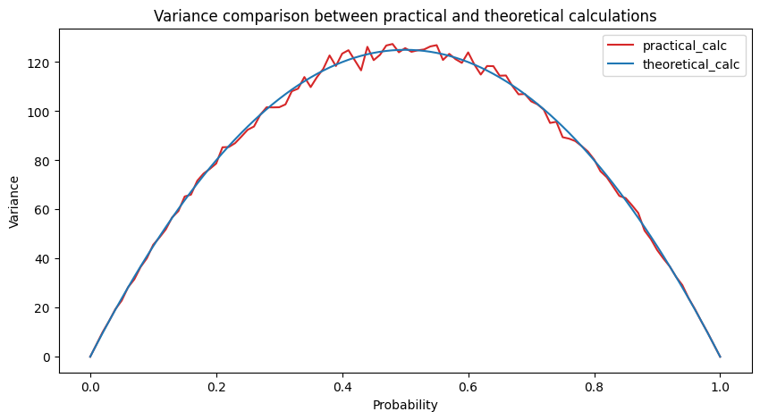

```python
import matplotlib.pyplot as plt

x = [p for p in prob]
y1 = practical_var
y2 = theoretical_var


fig = plt.figure(figsize=(10, 5))

plt.plot(x, y1, label = "practical_calc", color = "tab:red")
plt.plot(x, y2,label = "theoretical_calc", color = "tab:blue")

plt.xlabel('Probability')
plt.ylabel('Variance')
plt.title('Variance comparison between practical and theoretical calculations')
plt.legend()
plt.show()
```

Furthermore, we need to assess and compare the practical and theoretical averages.

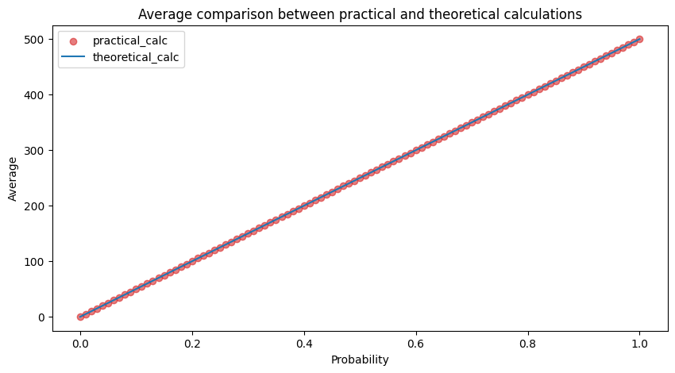

```python
x = [p for p in prob]
y1 = practical_avg
y2 =theoretical_avg

fig = plt.figure(figsize=(10, 5))

plt.scatter(x, y1, label = "practical_calc", color = "tab:red", alpha = 0.6)
plt.plot(x, y2,label = "theoretical_calc", color = "tab:blue")

plt.xlabel('Probability')
plt.ylabel('Average')
plt.title('Average comparison between practical and theoretical calculations')

plt.legend()
plt.show()
```

## **1_4:**

#### Difference between practical and theoretical Variances

When we look at the extremes (probability values of 0 and 1), the practical and theoretical variances are quite similar. However, when we consider the middle point (probability value of 0.5), the difference between these variances becomes more noticeable.

#### Difference Between Practical and Theoretical Averages

As you can see, the practical and theoretical averages are incredibly close to each other, almost indistinguishable! This can be attributed to the abundance of trials conducted (a whopping 5000 trials). If the number of trials were significantly smaller, let's say just 5 trials, the differences between the two would become more noticeable. Hence, we can draw the conclusion that as the number of trials approaches infinity, the gap between practical and theoretical calculations disappears entirely. This holds true for variance as well!

# **Part2:** Estimating the Binomial Distribution to Normal and Poisson Distributions

## **2_1:**

To start off, we should compare three different distributions using diagrams and plots.

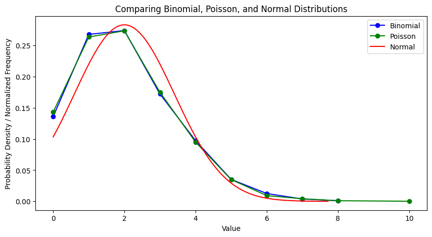

```python
import numpy as np
import matplotlib.pyplot as plt
from scipy.stats import binom, poisson, norm
from math import sqrt

size = 5000
n = 250
p = 0.008

lambda_poisson = n * p

mean_normal = n * p
std_normal = sqrt(n * p * (1-p))

binomial_data = np.random.binomial(n, p, size)
poisson_data = np.random.poisson(lambda_poisson, size)
normal_data = np.random.normal(mean_normal, std_normal, size)

plt.figure(figsize=(10, 5))

unique_binomial, counts_binomial = np.unique(binomial_data, return_counts=True)
frequency_for_binomial = counts_binomial / size
plt.plot(unique_binomial, frequency_for_binomial,marker='o', linestyle='-', color='blue', label='Binomial')

unique_poisson, counts_poisson = np.unique(poisson_data, return_counts=True)
frequency_for_poiss = counts_poisson / size
plt.plot(unique_poisson, frequency_for_poiss, marker='o', linestyle='-', color='green', label='Poisson')

x_values_normal = np.linspace(0, max(normal_data), 100)
normal_pdf_values = norm.pdf(x_values_normal, mean_normal, std_normal)
plt.plot(x_values_normal, normal_pdf_values, linestyle='-', color='red', label='Normal')

plt.title('Comparing Binomial, Poisson, and Normal Distributions')
plt.xlabel('Value')
plt.ylabel('Probability Density / Normalized Frequency')

plt.legend()
plt.show()
```

Now, presenting an alternative implementation of the comparison diagram:

```python
import plotly.graph_objs as go
from plotly.offline import download_plotlyjs, init_notebook_mode, iplot, plot

trace0 = go.Bar(x=unique_binomial,y=frequency_for_binomial,name="Binomial")

trace1 = go.Bar(x=unique_poisson, y=frequency_for_poiss, name="Poisson")

trace2 = go.Line(x=x_values_normal,y=normal_pdf_values,name="Normal")

data = [trace0, trace1,trace2]
layout = {"title": "Comparing Binomial, Poisson, and Normal Distributions"}

fig = go.Figure(data = data, layout=layout)
iplot(fig, show_link=False)
```

[interactive chart not shown]

## **2_2:**

In this case, we need to choose between two estimation methods: the Poisson distribution and the normal distribution. The Poisson distribution is a better choice for estimating the binomial distribution in this situation.

Here's why: The probability of dying in each collision is very low, close to zero at 0.008. There are a high number of collisions, around 250. When we multiply these values (250 * 0.008), we get a constant value of 2. This is important because it's a good reason to use the Poisson distribution for estimation.

If we tried to use the normal distribution, we would expect the probability of dying to be around 0.5, which is much higher than the actual probability. Since the probability is closer to zero than to the middle point, the Poisson distribution is a better choice for estimating the binomial distribution.

# **Part3:** Importance of the Normal Distribution (Section 1)

Here's the diagram for the given question with an average (mu) of 80 and a standard deviation (std) of 12:

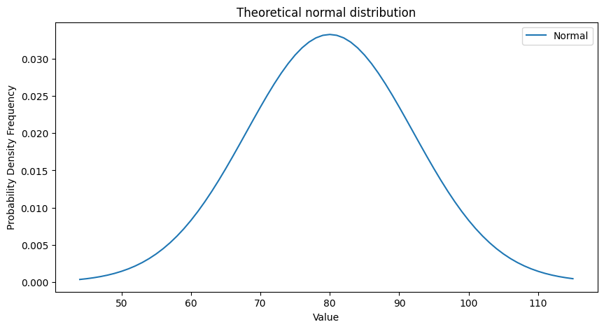

```python
import numpy as np
from scipy.stats import norm

mu = 80
sigma = 12
k = np.arange(mu - 3 * sigma, mu + 3 * sigma)

normal_pdf = norm.pdf(k, mu, sigma)
x = k
y = normal_pdf

fig = plt.figure(figsize=(10, 5))
plt.plot(x, y, label = "Normal")

plt.xlabel('Value')
plt.ylabel('Probability Density Frequency')
plt.title('Theoretical normal distribution')

plt.legend()
plt.show()
```

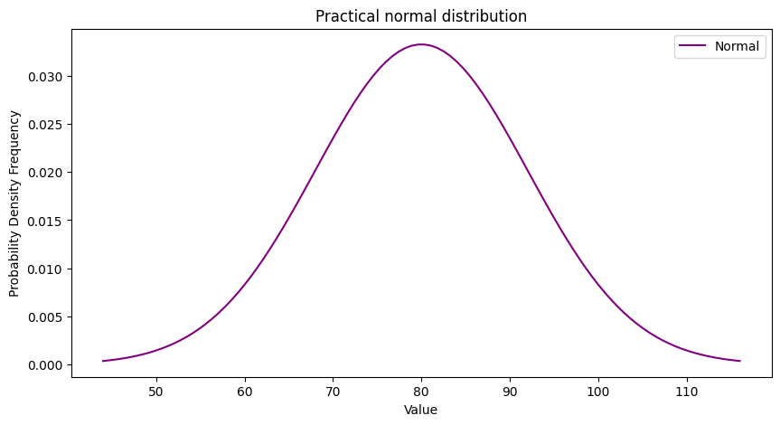

```python
normal_data = np.random.normal(loc=mu, scale=sigma, size=10000)

x_values_normal = np.linspace(mu - 3 * sigma, mu + 3 * sigma, 100)
normal_pdf_values = norm.pdf(x_values_normal, mu, sigma)
fig = plt.figure(figsize=(10, 5))
plt.plot(x_values_normal, normal_pdf_values, linestyle='-', color='purple', label='Normal')

plt.xlabel('Value')
plt.ylabel('Probability Density Frequency')
plt.title('Practical normal distribution')

plt.legend()
plt.show()
```

## **3_1:**

This answer is based on theoretical calculation.

```python
percentile_90 = norm.ppf(0.9, loc=mu, scale=sigma)
print (percentile_90)
```

```
95.3786187865352
```

Another way of implementing that could be:

```python
prob = np.arange(0, 1.01, 0.01)
percentile = [norm.ppf(p, loc=mu, scale=sigma) for p in prob]
last_decile = np.percentile(percentile, 90)
print (f"The last decile starts from the score of {last_decile}")
```

```
The last decile starts from the score of 95.3786187865352
```

If we implement it based on practical calculation, the answer would be this:

```python
samples = np.random.normal(loc=mu, scale=sigma, size=10000)

last_decile = np.percentile(samples, 90)
print (f"The last decile starts from the score of {last_decile}")
```

```
The last decile starts from the score of 95.51373497790935
```

## **3_2:**

The answer is based on practical calculation:

```python
samples = np.random.normal(loc=mu, scale=sigma, size=10000)

second_quartile = np.percentile(samples, 50)
third_quartile = np.percentile(samples, 75)

print(f"Scores between second and third Quartiles are from {second_quartile} to {third_quartile}")
```

```
Scores between second and third Quartiles are from 79.66379507634247 to 87.88837785999785
```

The answer is based on theoretical calculation:

```python
percentile = [norm.ppf(p, loc=mu, scale=sigma) for p in prob]

second_quartile = np.percentile(percentile, 50)
third_quartile = np.percentile(percentile, 75)

print(f"Scores between second and third Quartiles are from {second_quartile} to {third_quartile}" )
```

[output not shown]

## **3_3:**

We did the calculation of this part based on the theoretical one:

```python
CDF_right_Side = norm.cdf(90, loc=mu, scale=sigma)
CDF_left_side = norm.cdf(80, loc=mu, scale=sigma)

print(f"Probability of the score between 80 & 90 is: {CDF_right_Side - CDF_left_side}")
```

```
Probability of the score between 80 & 90 is: 0.29767161903635686
```

## **3_4:**

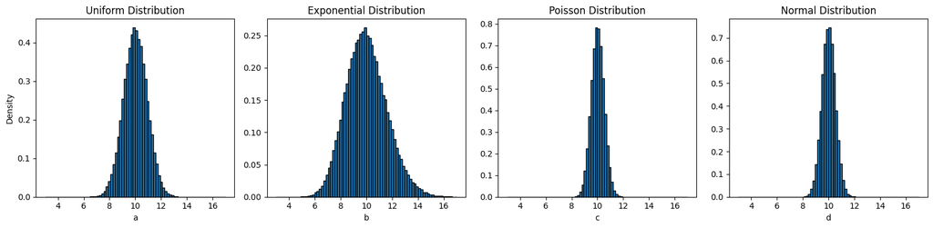

```python
import numpy as np
import matplotlib.pyplot as plt

size = 40
mu = 10
sigma = 3.3
low = 0
high = 20
trials = 100000

uniform_array = np.array([np.random.uniform(size=size, low=low, high=high) for _ in range(trials)])
a = np.array([np.average(i) for i in uniform_array])

exponential_array = np.array([np.random.exponential(scale=mu, size=size) for _ in range(trials)])
b = np.array([np.average(i) for i in exponential_array])

poisson_array = np.array([np.random.poisson(size=size, lam=mu) for _ in range(trials)])
c = np.array([np.average(i) for i in poisson_array])

normal_array = np.array([np.random.normal(size=size, loc=mu, scale=sigma) for _ in range(trials)])
d = np.array([np.average(i) for i in normal_array])

fig, axes = plt.subplots(1, 4, figsize=(16, 4))

axes[0].hist(a, bins=80, range=(3,17), density=True, edgecolor='black')
axes[0].set_xlabel('a')
axes[0].set_ylabel('Density')
axes[0].set_title('Uniform Distribution')

axes[1].hist(b, bins=80, range=(3,17), density=True, edgecolor='black')
axes[1].set_xlabel('b')
axes[1].set_title('Exponential Distribution')

axes[2].hist(c, bins=80, range=(3,17), density=True, edgecolor='black')
axes[2].set_xlabel('c')
axes[2].set_title('Poisson Distribution')

axes[3].hist(d, bins=80, range=(3,17), density=True, edgecolor='black')
axes[3].set_xlabel('d')
axes[3].set_title('Normal Distribution')

plt.tight_layout()

plt.show()
```

In the graphs provided, you may have noticed that I set the value of "mu" to 10. This choice was based on the assumption that it would serve as a good average for scores ranging from 0 to 20. Additionally, I set the value of "sigma" to 3.3, which represents the standard deviation. This decision was made because the majority of numbers fall within the range of 10 - 3 * 3.3 to 10 + 3 * 3.3. In other words, it is reasonable to assume that around 99.7 percent of scores lie between 0.1 and 19.9.

By observing the diagrams, we can see that they resemble a normal distribution, although they appear to have different standard deviations. This observation supports the Central Limit Theorem (CLT). Specifically:

The uniform distribution encompasses values between 0 and 20.

The exponential distribution has the value of "mu."

The Poisson distribution also aligns with the value of "mu."

The normal distribution, in this case, has a "mu" of 10 and a standard deviation of 3.3.

# **Part4:** Importance of the Normal Distribution (Section 2)

## **4_1:**

Here's a comparison diagram of the normal, Poisson, and binomial distributions to determine which of the Poisson and normal distributions provides a better estimation for the binomial distribution:

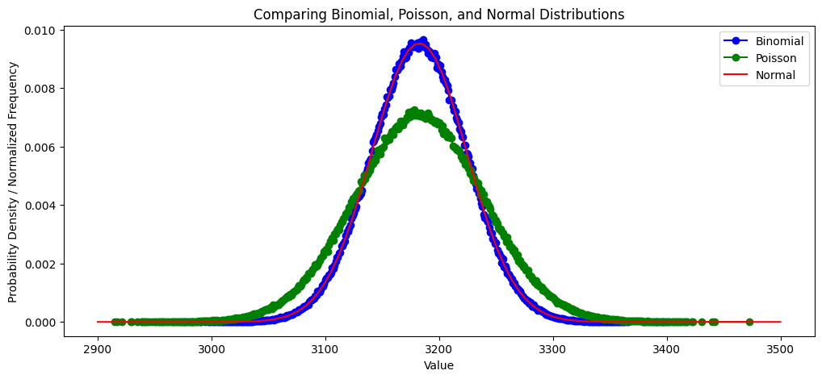

```python
import numpy as np
import matplotlib.pyplot as plt
from scipy.stats import binom, poisson, norm
import math

size = 1000000
n = 7072
p = 0.45
lambda_poisson = 3182.59
mean_normal = 3182.59
std_normal = 41.84

binomial_data = np.random.binomial(n, p, size)
poisson_data = np.random.poisson(lambda_poisson, size)
normal_data = np.random.normal(mean_normal, std_normal, size)

plt.figure(figsize=(12, 5))

unique_binomial, counts_binomial = np.unique(binomial_data, return_counts=True)
frequency_for_binomial = counts_binomial / size
plt.plot(unique_binomial, frequency_for_binomial, marker='o', linestyle='-', color='blue', label='Binomial')

unique_poisson, counts_poisson = np.unique(poisson_data, return_counts=True)
frequency_for_poiss = counts_poisson / size
plt.plot(unique_poisson, frequency_for_poiss, marker='o', linestyle='-', color='green', label='Poisson')

x_values_normal = np.linspace(2900,3500, 100)
normal_pdf_values = norm.pdf(x_values_normal, mean_normal, std_normal)
plt.plot(x_values_normal, normal_pdf_values, linestyle='-', color='red', label='Normal')

plt.title('Comparing Binomial, Poisson, and Normal Distributions')
plt.xlabel('Value')
plt.ylabel('Probability Density / Normalized Frequency')
plt.legend()
plt.show()
```

## **4_2:**

Based on the plots, it can be observed that the normal distribution is a more accurate estimation for the binomial distribution compared to the Poisson distribution in this case. This is because when the probability of getting wounded is around the midpoint (p = 0.45, close to p = 0.5), the normal distribution provides a better approximation for the binomial distribution. On the other hand, the Poisson distribution is more suitable for probabilities close to zero in the context of the binomial distribution. Therefore, in this particular scenario, the normal distribution is the preferable choice for estimating the binomial distribution.

Thanks for your attention.

My name is Alireza Karimi.

My SID is 810101492.

Hope you have a good day :)